# Step 1: Data understanding

- Import data
- Collect inital data
- Describe data
- Explore data
- Verify data quality
- Only talk about key insights, not every feature

(Hotz, 2023)

### Step 1.1 - Import necessary libraries and load the dataset

```python
import pandas as pd # For reading and analysing data
import numpy as np # For mathematical operations on arrays
import matplotlib.pyplot as plt # For visualisation
import seaborn as sns # For visualisation
# (So, 2023)
```

```python
# Import the datasets with Pandas read_csv function
df = pd.read_csv('repurchase_training.csv')
# (So, 2023)
```

### Step 1.2 - Collect inital data

```python
# Display the shape and first 5 rows of the df
df.head()
# (So, 2023)
```

|  | ID | Target | age_band | gender | car_model | car_segment | age_of_vehicle_years | sched_serv_warr | non_sched_serv_warr | sched_serv_paid | non_sched_serv_paid | total_paid_services | total_services | mth_since_last_serv | annualised_mileage | num_dealers_visited | num_serv_dealer_purchased |
| --- | --- | --- | --- | --- | --- | --- | --- | --- | --- | --- | --- | --- | --- | --- | --- | --- | --- |
| 0 | 1 | 0 | 3. 35 to 44 | Male | model_1 | LCV | 9 | 2 | 10 | 3 | 7 | 5 | 6 | 9 | 8 | 10 | 4 |
| 1 | 2 | 0 | NaN | NaN | model_2 | Small/Medium | 6 | 10 | 3 | 10 | 4 | 9 | 10 | 6 | 10 | 7 | 10 |
| 2 | 3 | 0 | NaN | Male | model_3 | Large/SUV | 9 | 10 | 9 | 10 | 9 | 10 | 10 | 7 | 10 | 6 | 10 |
| 3 | 5 | 0 | NaN | NaN | model_3 | Large/SUV | 5 | 8 | 5 | 8 | 4 | 5 | 6 | 4 | 10 | 9 | 7 |
| 4 | 6 | 0 | NaN | Female | model_2 | Small/Medium | 8 | 9 | 4 | 10 | 7 | 9 | 8 | 5 | 4 | 4 | 9 |

```python
# Display the shape of the df
df.shape
# (So, 2023)
```

```
(131337, 17)
```

```python
# Look at 5 random rows of the df
df.sample(5)
```

|  | ID | Target | age_band | gender | car_model | car_segment | age_of_vehicle_years | sched_serv_warr | non_sched_serv_warr | sched_serv_paid | non_sched_serv_paid | total_paid_services | total_services | mth_since_last_serv | annualised_mileage | num_dealers_visited | num_serv_dealer_purchased |
| --- | --- | --- | --- | --- | --- | --- | --- | --- | --- | --- | --- | --- | --- | --- | --- | --- | --- |
| 32673 | 38369 | 0 | NaN | NaN | model_1 | LCV | 2 | 4 | 5 | 9 | 10 | 10 | 3 | 5 | 4 | 8 | 5 |
| 55764 | 65525 | 0 | NaN | NaN | model_3 | Large/SUV | 7 | 10 | 10 | 10 | 10 | 10 | 10 | 3 | 9 | 8 | 8 |
| 68827 | 80828 | 0 | 2. 25 to 34 | Male | model_3 | Large/SUV | 8 | 5 | 8 | 7 | 6 | 6 | 5 | 9 | 4 | 3 | 1 |
| 63205 | 74226 | 0 | NaN | NaN | model_2 | Small/Medium | 3 | 2 | 3 | 1 | 4 | 2 | 2 | 4 | 3 | 8 | 4 |
| 1987 | 2327 | 0 | NaN | NaN | model_2 | Small/Medium | 4 | 8 | 7 | 7 | 7 | 7 | 8 | 6 | 4 | 6 | 9 |

### Step 1.3 - Describe data

```python
# Check how many rows and columns, how many non-null values and datatype of the datasets
df.info()
# (So, 2023)
```

```
<class 'pandas.core.frame.DataFrame'>
RangeIndex: 131337 entries, 0 to 131336
Data columns (total 17 columns):
 #   Column                     Non-Null Count   Dtype
---  ------                     --------------   -----
 0   ID                         131337 non-null  int64
 1   Target                     131337 non-null  int64
 2   age_band                   18962 non-null   object
 3   gender                     62029 non-null   object
 4   car_model                  131337 non-null  object
 5   car_segment                131337 non-null  object
 6   age_of_vehicle_years       131337 non-null  int64
 7   sched_serv_warr            131337 non-null  int64
 8   non_sched_serv_warr        131337 non-null  int64
 9   sched_serv_paid            131337 non-null  int64
 10  non_sched_serv_paid        131337 non-null  int64
 11  total_paid_services        131337 non-null  int64
 12  total_services             131337 non-null  int64
 13  mth_since_last_serv        131337 non-null  int64
 14  annualised_mileage         131337 non-null  int64
 15  num_dealers_visited        131337 non-null  int64
 16  num_serv_dealer_purchased  131337 non-null  int64
dtypes: int64(13), object(4)
memory usage: 17.0+ MB
```

```python
# Display all unique values for each column in the DataFrame
for col in df.columns:
    unique_values = df[col].unique()
    print(f'Unique values in {col}:')
    print(unique_values)
    print()

# (Print the Unique Values in Every Column in a Pandas Dataframe, 2020)
```

```
Unique values in ID:
[     1      2      3 ... 154137 154138 154139]

Unique values in Target:
[0 1]

Unique values in age_band:
['3. 35 to 44' nan '1. <25' '4. 45 to 54' '2. 25 to 34' '7. 75+'
 '5. 55 to 64' '6. 65 to 74']

Unique values in gender:
['Male' nan 'Female']

Unique values in car_model:
['model_1' 'model_2' 'model_3' 'model_5' 'model_6' 'model_4' 'model_7'
 'model_8' 'model_9' 'model_10' 'model_11' 'model_13' 'model_12'
 'model_14' 'model_15' 'model_16' 'model_17' 'model_18' 'model_19']

Unique values in car_segment:
['LCV' 'Small/Medium' 'Large/SUV' 'Other']

Unique values in age_of_vehicle_years:
[ 9  6  5  8  7  1  3  4 10  2]

Unique values in sched_serv_warr:
[ 2 10  8  9  4  1  3  7  5  6]

Unique values in non_sched_serv_warr:
[10  3  9  5  4  8  1  6  2  7]

Unique values in sched_serv_paid:
[ 3 10  8  5  2  6  1  4  9  7]

Unique values in non_sched_serv_paid:
[ 7  4  9  3  1  2  6  5 10  8]

Unique values in total_paid_services:
[ 5  9 10  6  8  1  2  7  3  4]

Unique values in total_services:
[ 6 10  8  4  2  1  3  5  9  7]

Unique values in mth_since_last_serv:
[ 9  6  7  4  5  8  1  3 10  2]

Unique values in annualised_mileage:
[ 8 10  4  5  6  1  7  3  9  2]

Unique values in num_dealers_visited:
[10  7  6  9  4  5  2  1  3  8]

Unique values in num_serv_dealer_purchased:
[ 4 10  7  9  8  3  1  6  2  5]
```

```python
df['Target'].value_counts()
```

```
0    127816
1      3521
Name: Target, dtype: int64
```

```python
df['car_segment'].value_counts()
```

```
Small/Medium    54553
Large/SUV       52120
LCV             24606
Other              58
Name: car_segment, dtype: int64
```

### Step 1.4 - Explore data

```python
# Analyze the distribution of numerical variables
numerical_columns = [
    'age_of_vehicle_years', 'sched_serv_warr', 'non_sched_serv_warr',
    'sched_serv_paid', 'non_sched_serv_paid', 'total_paid_services',
    'total_services', 'mth_since_last_serv', 'annualised_mileage',
    'num_dealers_visited', 'num_serv_dealer_purchased'
]

df[numerical_columns].describe()
```

|  | age_of_vehicle_years | sched_serv_warr | non_sched_serv_warr | sched_serv_paid | non_sched_serv_paid | total_paid_services | total_services | mth_since_last_serv | annualised_mileage | num_dealers_visited | num_serv_dealer_purchased |
| --- | --- | --- | --- | --- | --- | --- | --- | --- | --- | --- | --- |
| count | 131337.000000 | 131337.000000 | 131337.000000 | 131337.000000 | 131337.000000 | 131337.000000 | 131337.000000 | 131337.000000 | 131337.000000 | 131337.000000 | 131337.000000 |
| mean | 5.493022 | 5.452500 | 5.472517 | 5.452287 | 5.497050 | 5.481692 | 5.454967 | 5.469807 | 5.502836 | 5.485438 | 5.480778 |
| std | 2.843299 | 2.884328 | 2.870665 | 2.886528 | 2.878699 | 2.880408 | 2.875961 | 2.859756 | 2.854896 | 2.876772 | 2.867524 |
| min | 1.000000 | 1.000000 | 1.000000 | 1.000000 | 1.000000 | 1.000000 | 1.000000 | 1.000000 | 1.000000 | 1.000000 | 1.000000 |
| 25% | 3.000000 | 3.000000 | 3.000000 | 3.000000 | 3.000000 | 3.000000 | 3.000000 | 3.000000 | 3.000000 | 3.000000 | 3.000000 |
| 50% | 5.000000 | 5.000000 | 5.000000 | 5.000000 | 5.000000 | 5.000000 | 5.000000 | 5.000000 | 5.000000 | 5.000000 | 5.000000 |
| 75% | 8.000000 | 8.000000 | 8.000000 | 8.000000 | 8.000000 | 8.000000 | 8.000000 | 8.000000 | 8.000000 | 8.000000 | 8.000000 |
| max | 10.000000 | 10.000000 | 10.000000 | 10.000000 | 10.000000 | 10.000000 | 10.000000 | 10.000000 | 10.000000 | 10.000000 | 10.000000 |

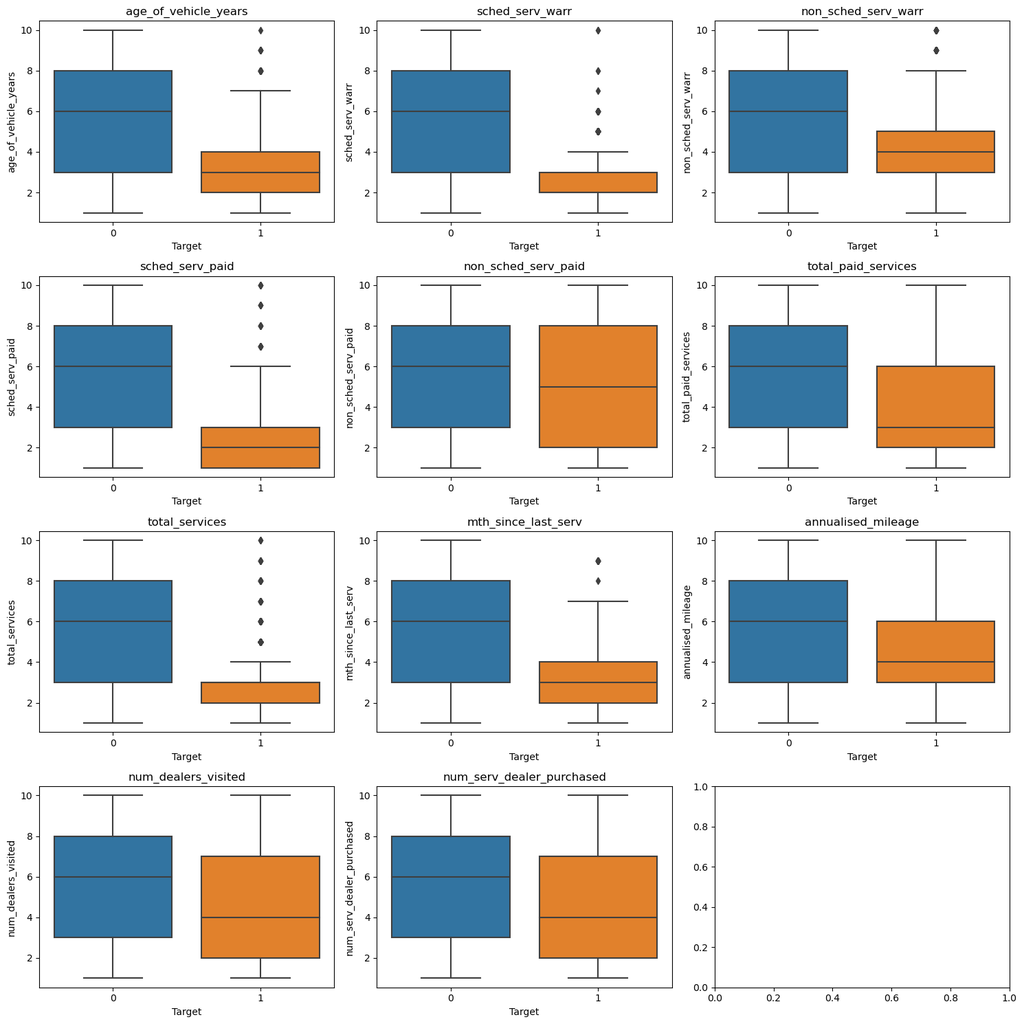

```python
# Visualize the distribution of numerical variables with box plots
fig, axes = plt.subplots(4, 3, figsize=(15, 15))
axes = axes.ravel()

for i, col in enumerate(numerical_columns):
    sns.boxplot(data=df, x='Target', y=col, ax=axes[i])
    axes[i].set_title(col)

plt.tight_layout()
plt.show()

#  (OpenAI, personal communication, February 24, 2023) - Prompt "Make subfigures for numerical columns"
```

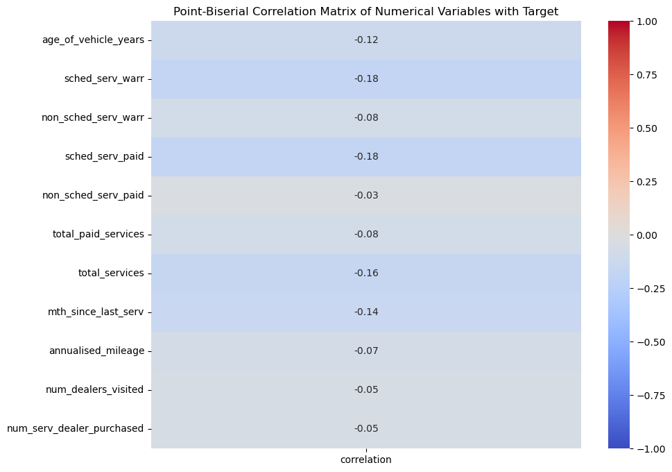

```python
from scipy.stats import pointbiserialr
# Compute point-biserial correlation coefficients (SciPy, 2014)
correlations = {}
for col in numerical_columns:
    corr, _ = pointbiserialr(df[col], df['Target'])
    correlations[col] = corr

# Create a DataFrame from the correlation dictionary (OpenAI, personal communication, February 24, 2023)
corr_df = pd.DataFrame.from_dict(correlations, orient='index', columns=['correlation'])

# Visualize the correlation matrix using a heatmap (So, 2023) (OpenAI, personal communication, February 24, 2023)
plt.figure(figsize=(10, 8))
sns.heatmap(corr_df, annot=True, cmap='coolwarm', fmt='.2f', vmin=-1, vmax=1)
plt.title("Point-Biserial Correlation Matrix of Numerical Variables with Target")
plt.show()
```

```python
# Analyse the distribution of categorical variables
categorical_columns = ['age_band', 'gender', 'car_model', 'car_segment']

for col in categorical_columns:
    print(f'\n{col} distribution:')
    print(df[col].value_counts(normalize=True))
```

```
age_band distribution:
4. 45 to 54    0.214007
3. 35 to 44    0.202141
2. 25 to 34    0.187111
5. 55 to 64    0.179148
6. 65 to 74    0.112857
7. 75+         0.053739
1. <25         0.050997
Name: age_band, dtype: float64

gender distribution:
Male      0.581534
Female    0.418466
Name: gender, dtype: float64

car_model distribution:
model_2     0.262614
model_5     0.187868
model_3     0.130001
model_1     0.116730
model_4     0.115390
model_7     0.062184
model_8     0.049057
model_10    0.024479
model_6     0.023383
model_9     0.007568
model_13    0.005436
model_12    0.004675
model_11    0.004660
model_15    0.002543
model_17    0.001165
model_16    0.000868
model_18    0.000769
model_14    0.000594
model_19    0.000015
Name: car_model, dtype: float64

car_segment distribution:
Small/Medium    0.415367
Large/SUV       0.396842
LCV             0.187350
Other           0.000442
Name: car_segment, dtype: float64
```

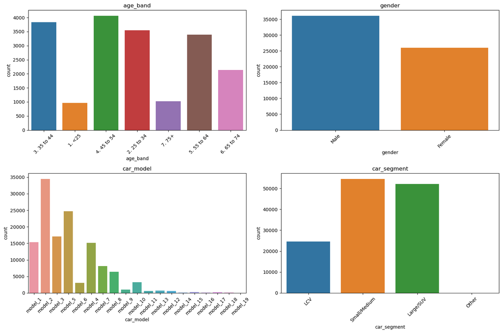

```python
# Visualize the distribution of categorical variables
fig, axes = plt.subplots(2, 2, figsize=(15, 10))
axes = axes.ravel()

for i, col in enumerate(categorical_columns):
    sns.countplot(data=df, x=col, ax=axes[i])
    axes[i].set_title(col)
    axes[i].tick_params(axis='x', rotation=45)

plt.tight_layout()
plt.show()

#  (OpenAI, personal communication, February 24, 2023) - Prompt "Make subfigures for categorical columns"
```

### Step 1.5 - Verify data quality

```python
# Check for duplicates
print("Duplicates in df:", df.duplicated().sum())
# Check for null values
print("Null values in df:", df.isnull().sum())
# (So, 2023)
```

```
Duplicates in df: 0
Null values in df: ID                                0
Target                            0
age_band                     112375
gender                        69308
car_model                         0
car_segment                       0
age_of_vehicle_years              0
sched_serv_warr                   0
non_sched_serv_warr               0
sched_serv_paid                   0
non_sched_serv_paid               0
total_paid_services               0
total_services                    0
mth_since_last_serv               0
annualised_mileage                0
num_dealers_visited               0
num_serv_dealer_purchased         0
dtype: int64
```

```python
df.isnull()
```

|  | ID | Target | age_band | gender | car_model | car_segment | age_of_vehicle_years | sched_serv_warr | non_sched_serv_warr | sched_serv_paid | non_sched_serv_paid | total_paid_services | total_services | mth_since_last_serv | annualised_mileage | num_dealers_visited | num_serv_dealer_purchased |
| --- | --- | --- | --- | --- | --- | --- | --- | --- | --- | --- | --- | --- | --- | --- | --- | --- | --- |
| 0 | False | False | False | False | False | False | False | False | False | False | False | False | False | False | False | False | False |
| 1 | False | False | True | True | False | False | False | False | False | False | False | False | False | False | False | False | False |
| 2 | False | False | True | False | False | False | False | False | False | False | False | False | False | False | False | False | False |
| 3 | False | False | True | True | False | False | False | False | False | False | False | False | False | False | False | False | False |
| 4 | False | False | True | False | False | False | False | False | False | False | False | False | False | False | False | False | False |
| ... | ... | ... | ... | ... | ... | ... | ... | ... | ... | ... | ... | ... | ... | ... | ... | ... | ... |
| 131332 | False | False | True | True | False | False | False | False | False | False | False | False | False | False | False | False | False |
| 131333 | False | False | True | True | False | False | False | False | False | False | False | False | False | False | False | False | False |
| 131334 | False | False | True | True | False | False | False | False | False | False | False | False | False | False | False | False | False |
| 131335 | False | False | True | True | False | False | False | False | False | False | False | False | False | False | False | False | False |
| 131336 | False | False | True | True | False | False | False | False | False | False | False | False | False | False | False | False | False |

131337 rows × 17 columns

# Step 2: Data Preparation

- Clean data
- Select data
- Split data

(Hotz, 2023)

### Step 2.1 - Clean data

```python
from sklearn.model_selection import train_test_split
# Stratified sampling to reduce dataset size while maintaining target representation (OpenAI, personal communication, February 24, 2023)
_, reduced_df = train_test_split(df, train_size=51337, stratify=df['Target'], random_state=42)

# Reset index (So, 2023)
reduced_df.reset_index(drop=True, inplace=True)

# Display the new shape of the dataset and target variable distribution
print("Reduced dataset shape:", reduced_df.shape)
print(reduced_df['Target'].value_counts())
```

```
Reduced dataset shape: (80000, 17)
0    77855
1     2145
Name: Target, dtype: int64
```

```python
# Create a copy of the dataframe
df_cleaned = reduced_df.copy()
# (So, 2023)
```

```python
# Unit Tests to see if the original df was copied correctly
assert isinstance(df_cleaned, pd.DataFrame)
assert df_cleaned.shape == reduced_df.shape
# (So, 2023)
```

```python
# Drop columns
df_cleaned = df_cleaned.drop(columns=['age_band', 'gender', 'ID'])
# (So, 2023)
```

### 2.2 Select data by feature engineering

- Total warranty services could indicate how much the customer values maintenance and repairs, which could be a good indicator of their likelihood to purchase a new car.
- Average number of services per year could give an idea of how frequently the customer uses their car and how well they maintain it, which could also be useful indicators of their likelihood to purchase a new car.

```python
# Total warranty services
df_cleaned['total_warranty_services'] = df_cleaned['sched_serv_warr'] + df_cleaned['non_sched_serv_warr']

# Average number of services per year
df_cleaned['avg_num_services_per_year'] = df_cleaned['total_services'] / df_cleaned['age_of_vehicle_years']
```

```python
# Check if the new features has a strong relationship with the target value
from scipy.stats import pointbiserialr

target = df_cleaned['Target']
total_warranty_services = df_cleaned['total_warranty_services']
avg_num_services_per_year = df_cleaned['avg_num_services_per_year']

correlation_total_warranty_services = pointbiserialr(target, total_warranty_services)
correlation_avg_num_services_per_year = pointbiserialr(target, avg_num_services_per_year)

print("Correlation between total_warranty_services and target:", correlation_total_warranty_services)
print("Correlation between avg_num_services_per_year and target:", correlation_avg_num_services_per_year)

# (SciPy, 2014)
```

```
Correlation between total_warranty_services and target: PointbiserialrResult(correlation=-0.151212096661223, pvalue=0.0)
Correlation between avg_num_services_per_year and target: PointbiserialrResult(correlation=-0.019000141022034234, pvalue=7.681570496900078e-08)
```

```python
# Drop avg_num_services_per_year because it has a very weak relationship
df_cleaned = df_cleaned.drop(columns=['avg_num_services_per_year'])
```

```python
df_cleaned.info()
```

```
<class 'pandas.core.frame.DataFrame'>
RangeIndex: 80000 entries, 0 to 79999
Data columns (total 15 columns):
 #   Column                     Non-Null Count  Dtype
---  ------                     --------------  -----
 0   Target                     80000 non-null  int64
 1   car_model                  80000 non-null  object
 2   car_segment                80000 non-null  object
 3   age_of_vehicle_years       80000 non-null  int64
 4   sched_serv_warr            80000 non-null  int64
 5   non_sched_serv_warr        80000 non-null  int64
 6   sched_serv_paid            80000 non-null  int64
 7   non_sched_serv_paid        80000 non-null  int64
 8   total_paid_services        80000 non-null  int64
 9   total_services             80000 non-null  int64
 10  mth_since_last_serv        80000 non-null  int64
 11  annualised_mileage         80000 non-null  int64
 12  num_dealers_visited        80000 non-null  int64
 13  num_serv_dealer_purchased  80000 non-null  int64
 14  total_warranty_services    80000 non-null  int64
dtypes: int64(13), object(2)
memory usage: 9.2+ MB
```

# Step 3: Modeling

- Select modeling techniques
- Generate test design
- Build model
- Assess model

(Hotz, 2023)

### 3.1 Generate test design by splitting data

ID column is not included to avoid overfitting as it is used to uniquely identify each record in the dataset and does not contribute to the prediction task.

Write why 75:25 ratio was chosen - Default value in sklearn

```python
# Extract features and target variable into Y and X
y = df_cleaned["Target"]
x = df_cleaned.drop("Target", axis=1)

# Import train_test_split from sklearn.model_selection - Already done in Step 2 but used to compile crucial info into Step 3
from sklearn.model_selection import train_test_split

# Split data into training and testing sets with 75:25 ratio
x_data, x_test, y_data, y_test = train_test_split(x, y, test_size=0.25, random_state=69)

# Split data into training and validation sets with 75:25 ratio
x_train, x_val, y_train, y_val = train_test_split(x, y, test_size=0.25, random_state=69)

# (So, 2023)
```

### 3.2 Import relevant libraries, prepare features for modelling

```python
from sklearn.compose import ColumnTransformer # Used to transform columns in DF for specified rules
from sklearn.preprocessing import OneHotEncoder # Used to convert categorical variables into binary features
from sklearn.metrics import accuracy_score, f1_score, precision_score, recall_score, make_scorer # Performance metrics for the modelling

# Define the categorical features - Updated because some were removed in Step 2.1
categorical_features = ['car_model', 'car_segment']

# Create the ColumnTransformer - (OpenAI, personal communication, February 24, 2023)
preprocessor = ColumnTransformer(
    transformers=[
        ('cat', OneHotEncoder(handle_unknown='ignore'), categorical_features)],
    remainder='passthrough'
)
```

### 3.3 Create baseline model

```python
# Find the mode of Y
y_mode = y.mode()

# Create a baseline prediction array with the mode of Y
baseline_prediction = np.full_like(y_train, y_mode)

# Evaluate the performance of the baseline model
accuracy = accuracy_score(y_train, baseline_prediction)

print("Baseline Model Accuracy:", accuracy)

# (So, 2023)
```

```
Baseline Model Accuracy: 0.9736
```

### 3.4 - Experiment 1: Train Logistic Regression Classifier

```python
from sklearn.linear_model import LogisticRegression

# Preprocess the training and validation sets
X_train_preprocessed = preprocessor.fit_transform(x_train)
X_val_preprocessed = preprocessor.transform(x_val)

# Instantiate the Logistic Regression model - (OpenAI, personal communication, February 24, 2023) - Prompt: Fix warning regarding failed convergence
log_reg = LogisticRegression(max_iter=2000)

# Fit the model with the training data
log_reg.fit(X_train_preprocessed, y_train)

# Make predictions on the training set
y_preds_train = log_reg.predict(X_train_preprocessed)

# Calculate the metrics for the training set
train_accuracy = accuracy_score(y_train, y_preds_train)
train_precision = precision_score(y_train, y_preds_train)
train_recall = recall_score(y_train, y_preds_train)
train_f1 = f1_score(y_train, y_preds_train)

# Make predictions on the validation set
y_preds_val = log_reg.predict(X_val_preprocessed)

# Calculate the metrics for the validation set
val_accuracy = accuracy_score(y_val, y_preds_val)
val_precision = precision_score(y_val, y_preds_val)
val_recall = recall_score(y_val, y_preds_val)
val_f1 = f1_score(y_val, y_preds_val)

# Display the results - (OpenAI, personal communication, February 24, 2023) Used to present results in a structured way
print("Training Set Metrics:")
print(f"Accuracy: {train_accuracy}")
print(f"Precision: {train_precision}")
print(f"Recall: {train_recall}")
print(f"F1: {train_f1}")

print("\nValidation Set Metrics:")
print(f"Accuracy: {val_accuracy}")
print(f"Precision: {val_precision}")
print(f"Recall: {val_recall}")
print(f"F1: {val_f1}")

# (So, 2023)
```

```
Training Set Metrics:
Accuracy: 0.9776933333333333
Precision: 0.84
Recall: 0.2256961406936981
F1: 0.3557951482479785

Validation Set Metrics:
Accuracy: 0.978
Precision: 0.7359550561797753
Recall: 0.20662460567823343
F1: 0.32266009852216754
```

```python
from sklearn.model_selection import GridSearchCV

# Define hyperparameter grid
param_grid = {
    'C': [0.1, 1, 10],
    'penalty': ['l1', 'l2'],
    'solver': ['liblinear', 'saga']
}

# Instantiate the logistic regression model
log_reg = LogisticRegression(max_iter=1000)

# Create the GridSearchCV object
grid_search = GridSearchCV(log_reg, param_grid, scoring='f1', verbose=1, n_jobs=-1)

# Fit the GridSearchCV object to the preprocessed data
grid_search.fit(X_train_preprocessed, y_train)

# Get the best parameters
best_params = grid_search.best_params_
best_estimator = grid_search.best_estimator_

print("Best parameters found:", best_params)

# Make predictions on the validation set using the best estimator
y_preds_val_best = best_estimator.predict(X_val_preprocessed)

# Calculate the metrics for the validation set using the best estimator
val_accuracy_best = accuracy_score(y_val, y_preds_val_best)
val_precision_best = precision_score(y_val, y_preds_val_best)
val_recall_best = recall_score(y_val, y_preds_val_best)
val_f1_best = f1_score(y_val, y_preds_val_best)

print("\nValidation set metrics (best estimator):")
print("Accuracy:", val_accuracy_best)
print("Precision:", val_precision_best)
print("Recall:", val_recall_best)
print("F1-score:", val_f1_best)

# (So, 2023), (OpenAI, personal communication, February 24, 2023) Used to debug issues creating GridSearchCV object
```

```
Fitting 5 folds for each of 12 candidates, totalling 60 fits
Best parameters found: {'C': 10, 'penalty': 'l2', 'solver': 'liblinear'}

Validation set metrics (best estimator):
Accuracy: 0.97804
Precision: 0.7374301675977654
Recall: 0.2082018927444795
F1-score: 0.3247232472324723
```

```python
from sklearn.model_selection import StratifiedKFold, cross_validate
from sklearn.metrics import make_scorer

# Preprocess the entire feature set 'x'
x_preprocessed = preprocessor.fit_transform(x)

# Define the stratified k-fold cross-validation
stratified_k_fold = StratifiedKFold(n_splits=5, random_state=42, shuffle=True)

# Define the scoring metrics
scoring_metrics = {
    'accuracy': 'accuracy',
    'precision': make_scorer(precision_score),
    'recall': make_scorer(recall_score),
    'f1': make_scorer(f1_score)
}

# Instantiate the Logistic Regression model with the best hyperparameters
log_reg_best = LogisticRegression(C=10, penalty='l2', solver='liblinear', max_iter=1000)

# Perform the cross-validation and calculate the metrics
cv_results_best = cross_validate(log_reg_best, x_preprocessed, y, cv=stratified_k_fold, scoring=scoring_metrics)

# Display the cross-validation results
print("Cross-Validation Metrics with Best Hyperparameters:")
print("Mean Accuracy:", cv_results_best['test_accuracy'].mean())
print("Mean Precision:", cv_results_best['test_precision'].mean())
print("Mean Recall:", cv_results_best['test_recall'].mean())
print("Mean F1 Score:", cv_results_best['test_f1'].mean())

# (So, 2023), (Sklearn.Model_Selection.StratifiedKFold, n.d.), (Explain Stratified K Fold Cross Validation in ML in Python, 2022)
```

```
Cross-Validation Metrics with Best Hyperparameters:
Mean Accuracy: 0.97801
Mean Precision: 0.8291569317682299
Mean Recall: 0.2267934072653492
Mean F1 Score: 0.35560274939398095
```

### 3.5 - Experiment 2: K-Nearest Neighbors

```python
from sklearn.neighbors import KNeighborsClassifier

# Preprocess the training and validation sets
X_train_preprocessed = preprocessor.fit_transform(x_train)
X_val_preprocessed = preprocessor.transform(x_val)

# Instantiate the K-Nearest Neighbors model
knn = KNeighborsClassifier(n_neighbors=5)

# Fit the model with the training data
knn.fit(X_train_preprocessed, y_train)

# Make predictions on the training set
y_preds_train = knn.predict(X_train_preprocessed)

# Calculate the metrics for the training set
train_accuracy = accuracy_score(y_train, y_preds_train)
train_precision = precision_score(y_train, y_preds_train)
train_recall = recall_score(y_train, y_preds_train)
train_f1 = f1_score(y_train, y_preds_train)

# Make predictions on the validation set
y_preds_val = knn.predict(X_val_preprocessed)

# Calculate the metrics for the validation set
val_accuracy = accuracy_score(y_val, y_preds_val)
val_precision = precision_score(y_val, y_preds_val)
val_recall = recall_score(y_val, y_preds_val)
val_f1 = f1_score(y_val, y_preds_val)

# Display the results
print("Training Set Metrics:")
print(f"Accuracy: {train_accuracy}")
print(f"Precision: {train_precision}")
print(f"Recall: {train_recall}")
print(f"F1: {train_f1}")

print("\nValidation Set Metrics:")
print(f"Accuracy: {val_accuracy}")
print(f"Precision: {val_precision}")
print(f"Recall: {val_recall}")
print(f"F1: {val_f1}")

# (So, 2023), (Shafi,2023), (OpenAI, personal communication, February 24, 2023)
```

```
Training Set Metrics:
Accuracy: 0.98984
Precision: 0.9452529452529452
Recall: 0.6663409868099658
F1: 0.7816618911174786

Validation Set Metrics:
Accuracy: 0.98688
Precision: 0.8768472906403941
Recall: 0.5615141955835962
F1: 0.6846153846153845
```

```python
from sklearn.model_selection import StratifiedKFold, cross_validate
from sklearn.metrics import make_scorer

# Define the stratified k-fold cross-validation - (OpenAI, personal communication, February 24, 2023) Used to decide metrics
stratified_k_fold = StratifiedKFold(n_splits=5, random_state=42, shuffle=True)

# Define the scoring metrics
scoring_metrics = {
    'accuracy': 'accuracy',
    'precision': make_scorer(precision_score),
    'recall': make_scorer(recall_score),
    'f1': make_scorer(f1_score)
}

# Instantiate the K-Nearest Neighbors model
knn = KNeighborsClassifier(n_neighbors=5)

# Preprocess the features
x_preprocessed = preprocessor.fit_transform(x)

# Perform the cross-validation and calculate the metrics
cv_results_knn = cross_validate(knn, x_preprocessed, y, cv=stratified_k_fold, scoring=scoring_metrics)

# Display the cross-validation results
print("K-Nearest Neighbors Cross-Validation Metrics:")
print("Mean Accuracy:", cv_results_knn['test_accuracy'].mean())
print("Mean Precision:", cv_results_knn['test_precision'].mean())
print("Mean Recall:", cv_results_knn['test_recall'].mean())
print("Mean F1 Score:", cv_results_knn['test_f1'].mean())

# (So, 2023), (Sklearn.Model_Selection.StratifiedKFold, n.d.), (Explain Stratified K Fold Cross Validation in ML in Python, 2022)
```

```
K-Nearest Neighbors Cross-Validation Metrics:
Mean Accuracy: 0.9871599999999999
Mean Precision: 0.9055189960117811
Mean Recall: 0.5818713694099336
Mean F1 Score: 0.7084448754605794
```

### 3.6 - Experiment 3: Train classifier using Support Vector Machine.

UndefinedMetricWarning: Precision is ill-defined and being set to 0.0 due to no predicted samples. Use `zero_division` parameter to control this behavior. _warn_prf(average, modifier, msg_start, len(result)) - Used zero_division to fix it.

```python
from sklearn.svm import SVC

# Preprocess the training and validation sets
X_train_preprocessed = preprocessor.fit_transform(x_train)
X_val_preprocessed = preprocessor.transform(x_val)

# Instantiate the SVM model with a different kernel and balanced class weights
svm = SVC(kernel='rbf', class_weight='balanced')

# Fit the model with the training data
svm.fit(X_train_preprocessed, y_train)

# Make predictions on the training set
y_preds_train = svm.predict(X_train_preprocessed)

# Calculate the metrics for the training set
train_accuracy = accuracy_score(y_train, y_preds_train)
train_precision = precision_score(y_train, y_preds_train, zero_division=0)
train_recall = recall_score(y_train, y_preds_train)
train_f1 = f1_score(y_train, y_preds_train)

# Make predictions on the validation set
y_preds_val = svm.predict(X_val_preprocessed)

# Calculate the metrics for the validation set
val_accuracy = accuracy_score(y_val, y_preds_val)
val_precision = precision_score(y_val, y_preds_val, zero_division=0)
val_recall = recall_score(y_val, y_preds_val)
val_f1 = f1_score(y_val, y_preds_val)

# Display the results
print("Training Set Metrics:")
print(f"Accuracy: {train_accuracy}")
print(f"Precision: {train_precision}")
print(f"Recall: {train_recall}")
print(f"F1: {train_f1}")

print("\nValidation Set Metrics:")
print(f"Accuracy: {val_accuracy}")
print(f"Precision: {val_precision}")
print(f"Recall: {val_recall}")
print(f"F1: {val_f1}")

# (So, 2023), (OpenAI, personal communication, February 24, 2023) Used to tweak parameters so execution time would be faster
```

```
Training Set Metrics:
Accuracy: 0.92925
Precision: 0.2681651855723994
Recall: 0.9715909090909091
F1: 0.420319541171651

Validation Set Metrics:
Accuracy: 0.93045
Precision: 0.28340292275574114
Recall: 0.9679144385026738
F1: 0.43843358901897456
```

```python
from sklearn.model_selection import StratifiedKFold, cross_validate
from sklearn.pipeline import Pipeline

# Create the pipeline for the preprocessing and the SVC model
svc_pipeline = Pipeline([
    ('preprocessor', preprocessor),
    ('classifier', SVC(kernel='rbf', class_weight='balanced'))
])

# Instantiate the StratifiedKFold object
skf = StratifiedKFold(n_splits=5)

# Define scoring metrics
scoring = {'accuracy': make_scorer(accuracy_score),
           'precision': make_scorer(precision_score, zero_division=0),
           'recall': make_scorer(recall_score),
           'f1': make_scorer(f1_score)}

# Perform stratified cross-validation
cv_results = cross_validate(svc_pipeline, x, y, cv=skf, scoring=scoring, n_jobs=-1)

# Print the results
print("Stratified Cross-Validation Metrics:")
print(f"Accuracy: {np.mean(cv_results['test_accuracy'])}")
print(f"Precision: {np.mean(cv_results['test_precision'])}")
print(f"Recall: {np.mean(cv_results['test_recall'])}")
print(f"F1: {np.mean(cv_results['test_f1'])}")

# (So, 2023), (Sklearn.Model_Selection.StratifiedKFold, n.d.), (Explain Stratified K Fold Cross Validation in ML in Python, 2022)
```

```
Stratified Cross-Validation Metrics:
Accuracy: 0.9294875000000001
Precision: 0.27057531034375193
Recall: 0.9608391608391609
F1: 0.42222555653694355
```

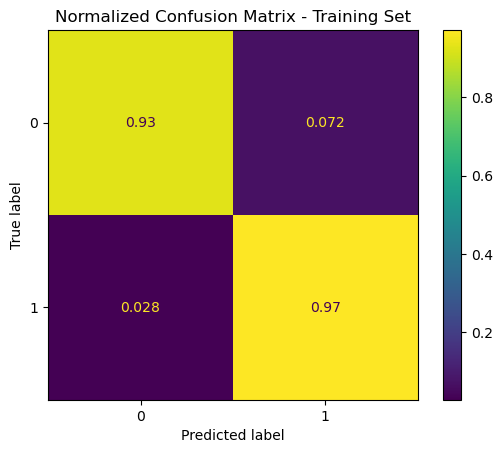

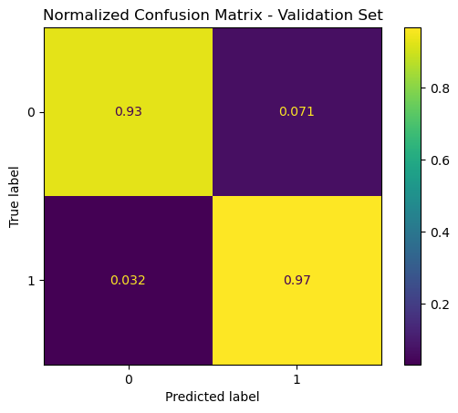

```python
from sklearn.metrics import confusion_matrix, ConfusionMatrixDisplay
import matplotlib.pyplot as plt

# Create a confusion matrix on the training set
train_cm = confusion_matrix(y_train, y_preds_train)

# Create a frequency confusion matrix on the training set
train_cm_freq = confusion_matrix(y_train, y_preds_train, normalize='true')

# Display the confusion matrix as a chart for the training set
disp_train = ConfusionMatrixDisplay(confusion_matrix=train_cm_freq, display_labels=['0', '1'])
disp_train.plot()
plt.title("Normalized Confusion Matrix - Training Set")
plt.show()

# Make predictions on the validation set
y_preds_val = svm.predict(X_val_preprocessed)

# Create a confusion matrix on the validation set
val_cm = confusion_matrix(y_val, y_preds_val)

# Create a frequency confusion matrix on the validation set
val_cm_freq = confusion_matrix(y_val, y_preds_val, normalize='true')

# Display the confusion matrix as a chart for the validation set
disp_val = ConfusionMatrixDisplay(confusion_matrix=val_cm_freq, display_labels=['0', '1'])
disp_val.plot()
plt.title("Normalized Confusion Matrix - Validation Set")
plt.show()

# (So, 2023), (OpenAI, personal communication, February 24, 2023) - Used to debug errors to make visual work
```

### 3.7 - Experiment 4: Decision Trees

```python
from sklearn.tree import DecisionTreeClassifier

# Preprocess the training and validation sets
X_train_preprocessed = preprocessor.fit_transform(x_train)
X_val_preprocessed = preprocessor.transform(x_val)

# Instantiate the Decision Tree Classifier
dtc = DecisionTreeClassifier(random_state=42)

# Fit the model with the training data
dtc.fit(X_train_preprocessed, y_train)

# Make predictions on the training set
y_preds_train = dtc.predict(X_train_preprocessed)

# Calculate the metrics for the training set
train_accuracy = accuracy_score(y_train, y_preds_train)
train_precision = precision_score(y_train, y_preds_train, zero_division=0)
train_recall = recall_score(y_train, y_preds_train)
train_f1 = f1_score(y_train, y_preds_train)

# Make predictions on the validation set
y_preds_val = dtc.predict(X_val_preprocessed)

# Calculate the metrics for the validation set
val_accuracy = accuracy_score(y_val, y_preds_val)
val_precision = precision_score(y_val, y_preds_val, zero_division=0)
val_recall = recall_score(y_val, y_preds_val)
val_f1 = f1_score(y_val, y_preds_val)

# Display the results
print("Training Set Metrics:")
print(f"Accuracy: {train_accuracy}")
print(f"Precision: {train_precision}")
print(f"Recall: {train_recall}")
print(f"F1: {train_f1}")

print("\nValidation Set Metrics:")
print(f"Accuracy: {val_accuracy}")
print(f"Precision: {val_precision}")
print(f"Recall: {val_recall}")
print(f"F1: {val_f1}")

# (So, 2023), (Navlani, 2023)
```

```
Training Set Metrics:
Accuracy: 1.0
Precision: 1.0
Recall: 1.0
F1: 1.0

Validation Set Metrics:
Accuracy: 0.98695
Precision: 0.7669039145907474
Recall: 0.768270944741533
F1: 0.7675868210151381
```

Change max_depth to prune the tree, so its less prone to overfitting.

```python
# Instantiate the Decision Tree Classifier - (OpenAI, personal communication, February 24, 2023) To fix overfitting
dtc2 = DecisionTreeClassifier(random_state=42, max_depth=5)

# Fit the model with the training data
dtc2.fit(X_train_preprocessed, y_train)

# Make predictions on the training set
y_preds_train = dtc2.predict(X_train_preprocessed)

# Calculate the metrics for the training set
train_accuracy = accuracy_score(y_train, y_preds_train)
train_precision = precision_score(y_train, y_preds_train, zero_division=0)
train_recall = recall_score(y_train, y_preds_train)
train_f1 = f1_score(y_train, y_preds_train)

# Make predictions on the validation set
y_preds_val = dtc2.predict(X_val_preprocessed)

# Calculate the metrics for the validation set
val_accuracy = accuracy_score(y_val, y_preds_val)
val_precision = precision_score(y_val, y_preds_val, zero_division=0)
val_recall = recall_score(y_val, y_preds_val)
val_f1 = f1_score(y_val, y_preds_val)

# Display the results
print("Training Set Metrics:")
print(f"Accuracy: {train_accuracy}")
print(f"Precision: {train_precision}")
print(f"Recall: {train_recall}")
print(f"F1: {train_f1}")

print("\nValidation Set Metrics:")
print(f"Accuracy: {val_accuracy}")
print(f"Precision: {val_precision}")
print(f"Recall: {val_recall}")
print(f"F1: {val_f1}")

# (So, 2023), (Navlani, 2023)
```

```
Training Set Metrics:
Accuracy: 0.98425
Precision: 0.8676639815880323
Recall: 0.476010101010101
F1: 0.6147574398695475

Validation Set Metrics:
Accuracy: 0.9825
Precision: 0.8600682593856656
Recall: 0.44919786096256686
F1: 0.5901639344262295
```

```python
from sklearn.model_selection import GridSearchCV
from sklearn.tree import DecisionTreeClassifier

# Define the hyperparameter grid
param_grid = {
    'criterion': ['gini', 'entropy'],
    'max_depth': [None, 10, 20],
    'min_samples_split': [2, 10]
}

# Instantiate the DecisionTreeClassifier
dtc3 = DecisionTreeClassifier()

# Instantiate the GridSearchCV object with the classifier and parameter grid
grid_search = GridSearchCV(
    estimator=dtc3,
    param_grid=param_grid,
    scoring='accuracy', # You can choose other scoring metrics if you prefer
    cv=5,
    n_jobs=-1
)

# Preprocess the data
X_data_preprocessed = preprocessor.fit_transform(x_data)

# Fit the GridSearchCV object to the preprocessed data and target variable
grid_search.fit(X_data_preprocessed, y_data)

# Print the best parameters
print("Best parameters found: ", grid_search.best_params_)

# Get the best estimator and use it to predict on the validation set
best_dtc3 = grid_search.best_estimator_

# Preprocess the validation data
X_val_preprocessed = preprocessor.transform(x_val)

# Make predictions on the validation set
y_val_preds = best_dtc3.predict(X_val_preprocessed)

# Calculate the metrics for the validation set
val_accuracy = accuracy_score(y_val, y_val_preds)
val_precision = precision_score(y_val, y_val_preds, zero_division=0)
val_recall = recall_score(y_val, y_val_preds)
val_f1 = f1_score(y_val, y_val_preds)

# Display the validation set metrics
print("\nValidation Set Metrics:")
print(f"Accuracy: {val_accuracy}")
print(f"Precision: {val_precision}")
print(f"Recall: {val_recall}")
print(f"F1: {val_f1}")

# (So, 2023), (OpenAI, personal communication, February 24, 2023) Used to debug issues creating GridSearchCV object
```

```
Best parameters found:  {'criterion': 'entropy', 'max_depth': 10, 'min_samples_split': 2}

Validation Set Metrics:
Accuracy: 0.9892
Precision: 0.8709677419354839
Recall: 0.7219251336898396
F1: 0.7894736842105263
```

```python
from sklearn.model_selection import StratifiedKFold, cross_val_score

# Instantiate the DecisionTreeClassifier with the best parameters found
best_dtc3 = DecisionTreeClassifier(criterion='entropy', max_depth=10, min_samples_split=2)

# Define the stratified cross-validation
cv = StratifiedKFold(n_splits=5)

# Preprocess the data
X_data_preprocessed = preprocessor.fit_transform(x_data)

# Perform stratified cross-validation
accuracy_scores = cross_val_score(best_dtc3, X_data_preprocessed, y_data, scoring='accuracy', cv=cv)
precision_scores = cross_val_score(best_dtc3, X_data_preprocessed, y_data, scoring='precision', cv=cv)
recall_scores = cross_val_score(best_dtc3, X_data_preprocessed, y_data, scoring='recall', cv=cv)
f1_scores = cross_val_score(best_dtc3, X_data_preprocessed, y_data, scoring='f1', cv=cv)

# Calculate the mean scores
mean_accuracy = np.mean(accuracy_scores)
mean_precision = np.mean(precision_scores)
mean_recall = np.mean(recall_scores)
mean_f1 = np.mean(f1_scores)

# Display the mean cross-validation scores
print("Mean Stratified Cross-Validation Metrics:")
print(f"Accuracy: {mean_accuracy}")
print(f"Precision: {mean_precision}")
print(f"Recall: {mean_recall}")
print(f"F1: {mean_f1}")

# (So, 2023), (Sklearn.Model_Selection.StratifiedKFold, n.d.), (Explain Stratified K Fold Cross Validation in ML in Python, 2022)
```

```
Mean Stratified Cross-Validation Metrics:
Accuracy: 0.9888
Precision: 0.8364666891000512
Recall: 0.714658786886555
F1: 0.7695059900667814
```

### 3.8 - Experiment 5: Train RandomForest

```python
from sklearn.ensemble import RandomForestClassifier

# Instantiate the RandomForestClassifier
rfc = RandomForestClassifier(random_state=42)

# Preprocess the training and validation sets
X_train_preprocessed = preprocessor.fit_transform(x_train)
X_val_preprocessed = preprocessor.transform(x_val)

# Fit the model with the training data
rfc.fit(X_train_preprocessed, y_train)

# Make predictions on the training set
y_preds_train = rfc.predict(X_train_preprocessed)

# Calculate the metrics for the training set - (OpenAI, personal communication, February 24, 2023) Fix error related to precision score
train_accuracy = accuracy_score(y_train, y_preds_train)
train_precision = precision_score(y_train, y_preds_train, zero_division=0)
train_recall = recall_score(y_train, y_preds_train)
train_f1 = f1_score(y_train, y_preds_train)

# Make predictions on the validation set
y_preds_val = rfc.predict(X_val_preprocessed)

# Calculate the metrics for the validation set
val_accuracy = accuracy_score(y_val, y_preds_val)
val_precision = precision_score(y_val, y_preds_val, zero_division=0)
val_recall = recall_score(y_val, y_preds_val)
val_f1 = f1_score(y_val, y_preds_val)

# Display the results
print("Training Set Metrics:")
print(f"Accuracy: {train_accuracy}")
print(f"Precision: {train_precision}")
print(f"Recall: {train_recall}")
print(f"F1: {train_f1}")

print("\nValidation Set Metrics:")
print(f"Accuracy: {val_accuracy}")
print(f"Precision: {val_precision}")
print(f"Recall: {val_recall}")
print(f"F1: {val_f1}")

# (So, 2023)
```

```
Training Set Metrics:
Accuracy: 1.0
Precision: 1.0
Recall: 1.0
F1: 1.0

Validation Set Metrics:
Accuracy: 0.99105
Precision: 0.9727722772277227
Recall: 0.7005347593582888
F1: 0.8145077720207254
```

Change max_depth to prune the tree, so its less prone to overfitting.

```python
from sklearn.ensemble import RandomForestClassifier

# Instantiate the RandomForestClassifier - (OpenAI, personal communication, February 24, 2023)
rfc = RandomForestClassifier(max_depth = 5, random_state=42)

# Preprocess the training and validation sets
X_train_preprocessed = preprocessor.fit_transform(x_train)
X_val_preprocessed = preprocessor.transform(x_val)

# Fit the model with the training data
rfc.fit(X_train_preprocessed, y_train)

# Make predictions on the training set
y_preds_train = rfc.predict(X_train_preprocessed)

# Calculate the metrics for the training set
train_accuracy = accuracy_score(y_train, y_preds_train)
train_precision = precision_score(y_train, y_preds_train, zero_division=0)
train_recall = recall_score(y_train, y_preds_train)
train_f1 = f1_score(y_train, y_preds_train)

# Make predictions on the validation set
y_preds_val = rfc.predict(X_val_preprocessed)

# Calculate the metrics for the validation set
val_accuracy = accuracy_score(y_val, y_preds_val)
val_precision = precision_score(y_val, y_preds_val, zero_division=0)
val_recall = recall_score(y_val, y_preds_val)
val_f1 = f1_score(y_val, y_preds_val)

# Display the results
print("Training Set Metrics:")
print(f"Accuracy: {train_accuracy}")
print(f"Precision: {train_precision}")
print(f"Recall: {train_recall}")
print(f"F1: {train_f1}")

print("\nValidation Set Metrics:")
print(f"Accuracy: {val_accuracy}")
print(f"Precision: {val_precision}")
print(f"Recall: {val_recall}")
print(f"F1: {val_f1}")

# (So, 2023)
```

```
Training Set Metrics:
Accuracy: 0.9740666666666666
Precision: 1.0
Recall: 0.017676767676767676
F1: 0.0347394540942928

Validation Set Metrics:
Accuracy: 0.97235
Precision: 1.0
Recall: 0.0142602495543672
F1: 0.0281195079086116
```

```python
from sklearn.model_selection import GridSearchCV

# Define the hyperparameter grid
param_grid = {
    'n_estimators': [10, 50, 100],
    'criterion': ['gini', 'entropy'],
    'max_depth': [5, 10, 20],
    'min_samples_split': [2, 10],
    'min_samples_leaf': [1, 5]
}

# Instantiate the GridSearchCV object
grid_search_rf = GridSearchCV(RandomForestClassifier(max_depth = 5,random_state=42), param_grid, cv=5, scoring='accuracy', n_jobs=-1)

# Fit the GridSearchCV object to the preprocessed training data
grid_search_rf.fit(X_train_preprocessed, y_train)

# Print the best combination of hyperparameters
print("Best combination of hyperparameters (RandomForest):", grid_search_rf.best_params_)

# Retrieve the best estimator and make predictions
best_estimator_rf = grid_search_rf.best_estimator_
y_preds_train_rf_opt = best_estimator_rf.predict(X_train_preprocessed)
y_preds_val_rf_opt = best_estimator_rf.predict(X_val_preprocessed)

# Calculate the accuracy, precision, recall, and F1 scores
train_accuracy_rf_opt = accuracy_score(y_train, y_preds_train_rf_opt)
train_precision_rf_opt = precision_score(y_train, y_preds_train_rf_opt, zero_division=0)
train_recall_rf_opt = recall_score(y_train, y_preds_train_rf_opt)
train_f1_rf_opt = f1_score(y_train, y_preds_train_rf_opt)

val_accuracy_rf_opt = accuracy_score(y_val, y_preds_val_rf_opt)
val_precision_rf_opt = precision_score(y_val, y_preds_val_rf_opt, zero_division=0)
val_recall_rf_opt = recall_score(y_val, y_preds_val_rf_opt)
val_f1_rf_opt = f1_score(y_val, y_preds_val_rf_opt)

print("\nTraining Set Metrics:")
print(f"Accuracy: {train_accuracy_rf_opt}")
print(f"Precision: {train_precision_rf_opt}")
print(f"Recall: {train_recall_rf_opt}")
print(f"F1: {train_f1_rf_opt}")

print("\nValidation Set Metrics:")
print(f"Accuracy: {val_accuracy_rf_opt}")
print(f"Precision: {val_precision_rf_opt}")
print(f"Recall: {val_recall_rf_opt}")
print(f"F1: {val_f1_rf_opt}")

# (So, 2023), (OpenAI, personal communication, February 24, 2023) Used to debug issues creating GridSearchCV object
```

```
Best combination of hyperparameters (RandomForest): {'criterion': 'entropy', 'max_depth': 20, 'min_samples_leaf': 1, 'min_samples_split': 2, 'n_estimators': 100}

Training Set Metrics:
Accuracy: 0.99935
Precision: 1.0
Recall: 0.9753787878787878
F1: 0.987535953978907

Validation Set Metrics:
Accuracy: 0.99115
Precision: 0.98
Recall: 0.6987522281639929
F1: 0.8158168574401664
```

```python
from sklearn.ensemble import RandomForestClassifier
from sklearn.model_selection import StratifiedKFold, cross_validate
from sklearn.pipeline import Pipeline

# Create a RandomForest classifier with the optimal hyperparameters
optimal_rf = RandomForestClassifier(
    criterion='entropy',
    max_depth=20,
    min_samples_leaf=1,
    min_samples_split=2,
    n_estimators=100,
    random_state=42
)

# Create a pipeline with the preprocessor and the RandomForest classifier
rf_pipeline = Pipeline([
    ('preprocessor', preprocessor),
    ('classifier', optimal_rf)
])

# Define the scoring metrics
scoring = {
    'accuracy': make_scorer(accuracy_score),
    'precision': make_scorer(precision_score, zero_division=0),
    'recall': make_scorer(recall_score),
    'f1': make_scorer(f1_score)
}

# Perform stratified cross-validation
skf = StratifiedKFold(n_splits=5, shuffle=True, random_state=42)
rf_cv_results = cross_validate(rf_pipeline, x_train, y_train, cv=skf, scoring=scoring, n_jobs=-1)

# Print the mean scores
print("Stratified Cross-Validation Results:")
print(f"Mean Accuracy: {rf_cv_results['test_accuracy'].mean()}")
print(f"Mean Precision: {rf_cv_results['test_precision'].mean()}")
print(f"Mean Recall: {rf_cv_results['test_recall'].mean()}")
print(f"Mean F1: {rf_cv_results['test_f1'].mean()}")

# (So, 2023), (Sklearn.Model_Selection.StratifiedKFold, n.d.), (Explain Stratified K Fold Cross Validation in ML in Python, 2022), (OpenAI, personal communication, February 24, 2023)
```

```
Stratified Cross-Validation Results:
Mean Accuracy: 0.9906666666666666
Mean Precision: 0.9524855563316283
Mean Recall: 0.6805654274647606
Mean F1: 0.7936830113651381
```

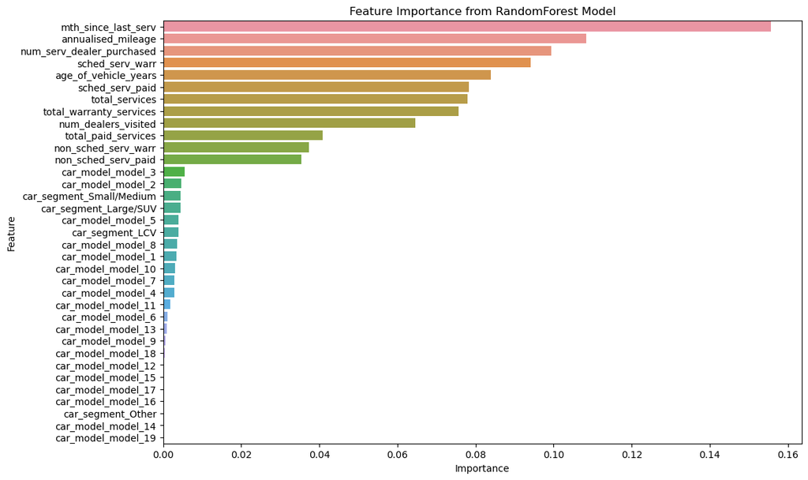

```python
import matplotlib.pyplot as plt
import seaborn as sns

# Get feature importances from the best RandomForest estimator
feature_importances = best_estimator_rf.feature_importances_

# Get feature names from the preprocessor
feature_names = preprocessor.transformers_[0][1].get_feature_names_out(categorical_features)

# Combine the numerical and categorical feature names
all_feature_names = np.concatenate([feature_names, x_train.columns[~x_train.columns.isin(categorical_features)]])

# Create a DataFrame with feature importances and names
importance_df = pd.DataFrame({'feature': all_feature_names, 'importance': feature_importances})

# Sort the DataFrame by importance
importance_df = importance_df.sort_values('importance', ascending=False)

# Plot feature importances
plt.figure(figsize=(12, 8))
sns.barplot(x='importance', y='feature', data=importance_df)
plt.title('Feature Importance from RandomForest Model')
plt.xlabel('Importance')
plt.ylabel('Feature')
plt.show()

# (So, 2023), (OpenAI, personal communication, February 24, 2023) - Used to make visualisation
```

# Step 4: Evaluation

- Evaluate results
- Review process
- Determine next steps

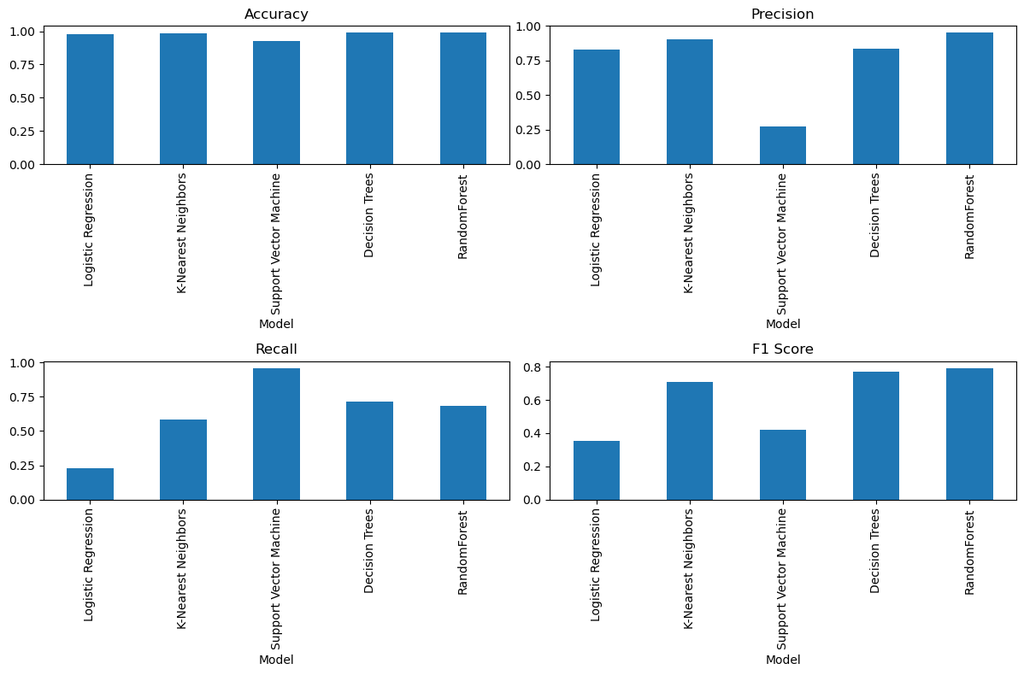

```
                        Accuracy  Precision   Recall       F1
Model
Logistic Regression      0.97801    0.82916  0.22679  0.35560
K-Nearest Neighbors      0.98716    0.90552  0.58187  0.70844
Support Vector Machine   0.92949    0.27058  0.96084  0.42223
Decision Trees           0.98880    0.83647  0.71466  0.76951
RandomForest             0.99067    0.95249  0.68057  0.79368
```

```python
# Create a DataFrame with the metrics for each model
results = pd.DataFrame({
    'Model': ['Logistic Regression', 'K-Nearest Neighbors', 'Support Vector Machine', 'Decision Trees', 'RandomForest'],
    'Accuracy': [0.97801, 0.98716, 0.92949, 0.9888, 0.99067],
    'Precision': [0.82916, 0.90552, 0.27058, 0.83647, 0.95249],
    'Recall': [0.22679, 0.58187, 0.96084, 0.71466, 0.68057],
    'F1': [0.35560, 0.70844, 0.42223, 0.76951, 0.79368]
})

# Set the index to the model name
results.set_index('Model', inplace=True)

# Create bar plots for each metric
fig, axes = plt.subplots(nrows=2, ncols=2, figsize=(12, 8))

results['Accuracy'].plot(kind='bar', ax=axes[0, 0], title='Accuracy')
results['Precision'].plot(kind='bar', ax=axes[0, 1], title='Precision')
results['Recall'].plot(kind='bar', ax=axes[1, 0], title='Recall')
results['F1'].plot(kind='bar', ax=axes[1, 1], title='F1 Score')

# Add space between subplots
plt.tight_layout()

# Display the plots
plt.show()

# Print the results table
print(results)

# (So, 2023), (OpenAI, personal communication, February 24, 2023) - Used to make visualisation correctly
```

```python
sorted_results = results.sort_values(by='F1', ascending=False)
print(sorted_results)
# (So, 2023)
```

```
                        Accuracy  Precision   Recall       F1
Model
RandomForest             0.99067    0.95249  0.68057  0.79368
Decision Trees           0.98880    0.83647  0.71466  0.76951
K-Nearest Neighbors      0.98716    0.90552  0.58187  0.70844
Support Vector Machine   0.92949    0.27058  0.96084  0.42223
Logistic Regression      0.97801    0.82916  0.22679  0.35560
```